# Connecticut temperatures

Andrew Ba Tran

August 23, 2015

This is a [walkthrough](http://trendct.github.io/weather/temperatures.html) to accompany the TrendCT story: [How hot has it been in Connecticut this summer](http://trendct.org/2015/08/24/how-hot-has-it-been-in-connecticut-this-summer)?

These visualizations would not have been possible without the excellent work from Bradley Boehmke’s [Dayton’s Weather in 2014](https://rpubs.com/bradleyboehmke/weather_graphic) and Randy Olson’s [The New York Times weather chart redux](http://www.randalolson.com/2015/08/13/the-new-york-times-weather-chart-redux/).

Before we begin, you need a dataframe of historical temperature data. Please refer to the wunderground_scraper.R script on how to collect the appropriate data. This is how the data should look.

```r
library(knitr)
airp <- read.csv("KHFD.csv", stringsAsFactors=FALSE)

# Label the town for the chart title
town <- "Hartford"

kable(head(airp))
```

| row | date | actual_mean_temp | actual_min_temp | actual_max_temp | average_min_temp | average_max_temp | record_min_temp | record_max_temp | record_min_temp_year | record_max_temp_year |
| --- | --- | --- | --- | --- | --- | --- | --- | --- | --- | --- |
| 1 | 6/1/14 | 60 | 45 | 77 | 54 | 75 | 39 | 95 | 1967 | 1937 |
| 2 | 6/2/14 | 67 | 54 | 80 | 53 | 76 | 43 | 89 | 1946 | 1934 |
| 3 | 6/3/14 | 70 | 57 | 84 | 53 | 76 | 37 | 97 | 1986 | 1919 |
| 4 | 6/4/14 | 68 | 62 | 75 | 53 | 75 | 41 | 97 | 1984 | 1925 |
| 5 | 6/5/14 | 65 | 61 | 70 | 53 | 75 | 44 | 96 | 1944 | 1925 |
| 6 | 6/6/14 | 66 | 59 | 75 | 53 | 76 | 40 | 96 | 1964 | 1925 |

It has max and min average, actual, and record temperatures for each day.

Now let’s load the packages to work the data into something to visualize with

```r
library(dplyr)
```

```r
library(tidyr)
library(ggplot2)
```

Restructuring the data so it plays nice with ggplot2

```r
airp2 <- gather(airp, "type", "temp", 4:11)
```

Function to turn y-axis labels into degree formatted values and set the range from -20 to 100.

```r
dgr_fmt <- function(x, ...) {
  parse(text = paste(x, "*degree", sep = ""))
}
a <- dgr_fmt(seq(-20,100, by=10))
```

Bringing in a package that will allow use of Google fonts to match TrendCT style.

```r
library(extrafont)
```

Now plotting the chart layer by layer with geom_linerange()

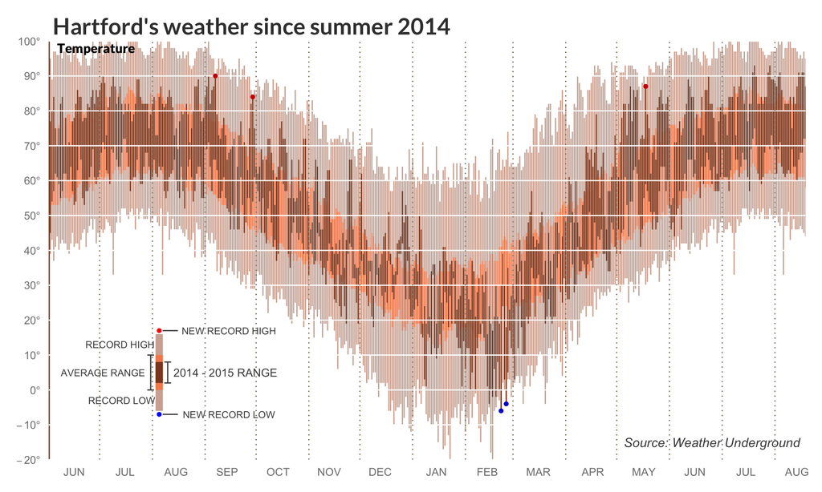

```r
p <- ggplot(airp, aes(row, average_min_temp)) +
  theme(plot.background = element_blank(),
        panel.grid.minor = element_blank(),
        panel.grid.major = element_blank(),
        panel.border = element_blank(),
        panel.background = element_blank(),
        axis.ticks = element_blank(),
        axis.title = element_blank()) +
  geom_linerange(airp, mapping=aes(x=row, ymin=record_min_temp, ymax=record_max_temp), colour = "sienna", alpha=.5)

p <- p +
  geom_linerange(airp, mapping=aes(x=row, ymin=average_min_temp, ymax=average_max_temp), colour = "sienna1", alpha=.8)

p <- p +
  geom_linerange(airp, mapping=aes(x=row, ymin=actual_min_temp, ymax=actual_max_temp), colour = "sienna4") +
  geom_vline(xintercept = 0, colour = "sienna4", linetype=1, size=1)

# The colors used in the chart layers above can be replaced with any from
# http://sape.inf.usi.ch/quick-reference/ggplot2/colour

# Make the grid look pretty

p <- p +
  geom_hline(yintercept = -20, colour = "white", linetype=1) +
  geom_hline(yintercept = -10, colour = "white", linetype=1) +
  geom_hline(yintercept = 0, colour = "white", linetype=1) +
  geom_hline(yintercept = 10, colour = "white", linetype=1) +
  geom_hline(yintercept = 20, colour = "white", linetype=1) +
  geom_hline(yintercept = 30, colour = "white", linetype=1) +
  geom_hline(yintercept = 40, colour = "white", linetype=1) +
  geom_hline(yintercept = 50, colour = "white", linetype=1) +
  geom_hline(yintercept = 60, colour = "white", linetype=1) +
  geom_hline(yintercept = 70, colour = "white", linetype=1) +
  geom_hline(yintercept = 80, colour = "white", linetype=1) +
  geom_hline(yintercept = 90, colour = "white", linetype=1) +
  geom_hline(yintercept = 100, colour = "white", linetype=1)

# Identifying the months based on number of days

p <- p +
  #June - 30
  geom_vline(xintercept = 30, colour = "wheat4", linetype=3, size=.5) +
  #July - 31
  geom_vline(xintercept = 61, colour = "wheat4", linetype=3, size=.5) +
  # August - 31
  geom_vline(xintercept = 92, colour = "wheat4", linetype=3, size=.5) +
  # September - 30
  geom_vline(xintercept = 122, colour = "wheat4", linetype=3, size=.5) +
  # October 31
  geom_vline(xintercept = 153, colour = "wheat4", linetype=3, size=.5) +
  # November - 30
  geom_vline(xintercept = 183, colour = "wheat4", linetype=3, size=.5) +
  # December - 31
  geom_vline(xintercept = 214, colour = "wheat4", linetype=3, size=.5) +
  # January - 31
  geom_vline(xintercept = 245, colour = "wheat4", linetype=3, size=.5) +
  # February - 28
  geom_vline(xintercept = 273, colour = "wheat4", linetype=3, size=.5) +
  # March - 31
  geom_vline(xintercept = 304, colour = "wheat4", linetype=3, size=.5) +
  # April - 30
  geom_vline(xintercept = 334, colour = "wheat4", linetype=3, size=.5) +
  # May - 31
  geom_vline(xintercept = 365, colour = "wheat4", linetype=3, size=.5) +
  # June - 30
  geom_vline(xintercept = 396, colour = "wheat4", linetype=3, size=.5) +
  # July - 31
  geom_vline(xintercept = 427, colour = "wheat4", linetype=3, size=.5)
# August - 31 (19 so far)

# Establishing the x axis
p <- p +
  coord_cartesian(ylim = c(-20,100)) +
  scale_y_continuous(breaks = seq(-20,100, by=10), labels = a) +
  scale_x_continuous(expand = c(0, 0),
                     breaks = c(15,45,75,105,135,165,195,228,258,288,320,350, 380, 410, 440),
                     labels = c("JUN", "JUL", "AUG", "SEP", "OCT",
                                "NOV", "DEC", "JAN", "FEB", "MAR",
                                "APR", "MAY", "JUN", "JUL", "AUG"))

# Identifying the record-breaking days by comparing actual vs record
rlow3 <- airp[airp$actual_min_temp<=airp$record_min_temp,]
rhigh3 <- airp[airp$actual_max_temp>=airp$record_max_temp,]

# Adding them to the chart with specific colors
p <- p +
  geom_point(data=rlow3, aes(x=row, y=record_min_temp), colour="blue3") +
  geom_point(data=rhigh3, aes(x=row, y=record_max_temp), colour="red3")

# Adding a title based on the variable set above
title <- paste0(town, "'s weather since summer 2014")

# Setting the title
p <- p +
  ggtitle(title) +
  theme(plot.title=element_text(face="bold",hjust=.012,vjust=.8,colour="#3C3C3C",size=20, family="Lato")) +
  annotate("text", x = 28, y = 98, label = "Temperature", size=4, fontface="bold", family="Lato Black")

# Now for the legend
p <- p +
  annotate("segment", x = 65, xend = 65, y = -6, yend = 16, colour = "sienna", , alpha=.5, size=3) +
  annotate("segment", x = 65, xend = 65, y = 0, yend = 10, colour = "sienna1", , alpha=.8, size=3) +
  annotate("segment", x = 65, xend = 65, y = 2, yend = 8, colour = "sienna4", size=3) +

  annotate("segment", x = 58, xend = 62, y = 10, yend = 10, colour = "gray30", size=.5) +
  annotate("segment", x = 58, xend = 62, y = 0, yend = 0, colour = "gray30", size=.5) +
  annotate("segment", x = 60, xend = 60, y = 10, yend = 0, colour = "gray30", size=.5) +

  annotate("text", x = 32, y = 5, label = "AVERAGE RANGE", size=3, colour="gray30") +

  annotate("segment", x = 68, xend = 72, y = 8, yend = 8, colour = "gray30", size=.5) +
  annotate("segment", x = 68, xend = 72, y = 2, yend = 2, colour = "gray30", size=.5) +
  annotate("segment", x = 70, xend = 70, y = 8, yend = 2, colour = "gray30", size=.5) +

  annotate("text", x = 104, y = 5, label = "2014 - 2015 RANGE", size=3.5, colour="gray30") +
  annotate("text", x = 42, y = 13, label = "RECORD HIGH", size=3, colour="gray30") +
  annotate("text", x = 43, y = -3, label = "RECORD LOW", size=3, colour="gray30") +

  annotate("segment", x = 67, xend = 76, y = 17, yend = 17, colour = "gray30", size=.5) +
  annotate("segment", x = 67, xend = 76, y = -7, yend = -7, colour = "gray30", size=.5) +

  annotate("point", x = 65, y = 17, colour = "red", size = 2) +
  annotate("point", x = 65, y = -7, colour = "blue", size = 2) +
  annotate("text", x = 106, y = 17, label = "NEW RECORD HIGH", size=3, colour="gray30") +
  annotate("text", x = 106, y = -7, label = "NEW RECORD LOW", size=3, colour="gray30") +
  annotate("text", x = 390, y = -15, label = "Source: Weather Underground", size=4, fontface="italic", colour="gray30")
print(p)
```

Pretty cool. To generate a new visualization, just rename the CSV and town name in the first chunk of code above.

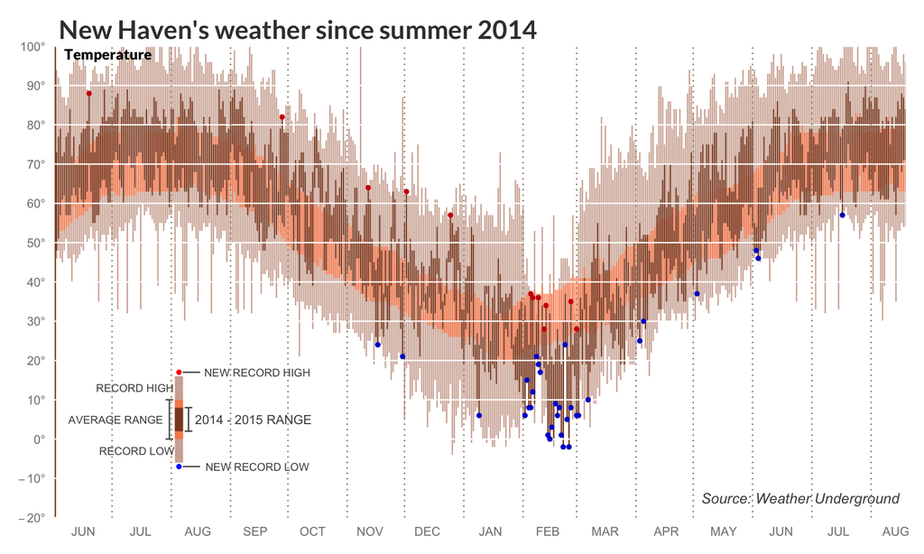

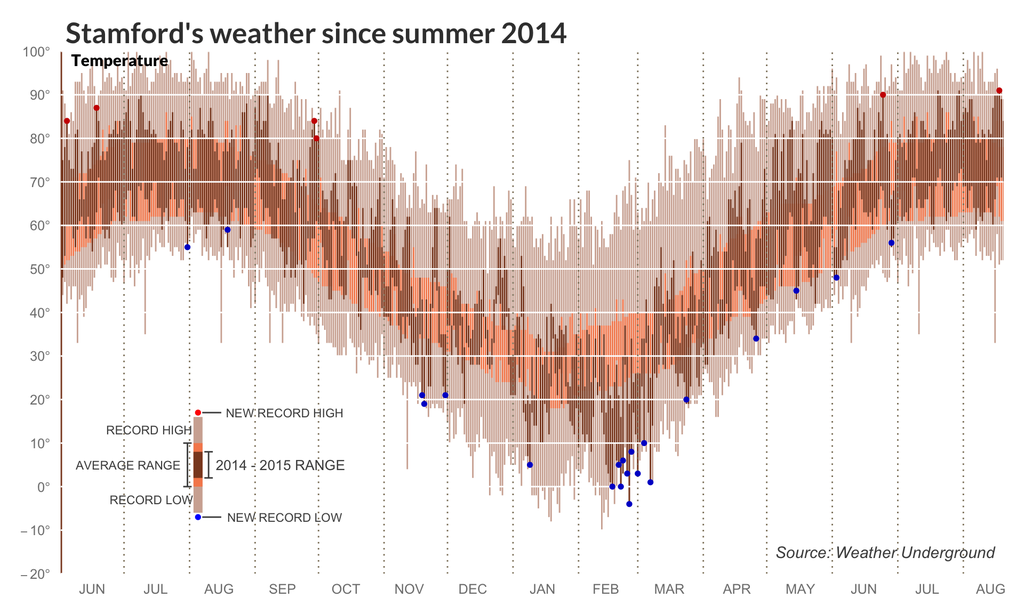

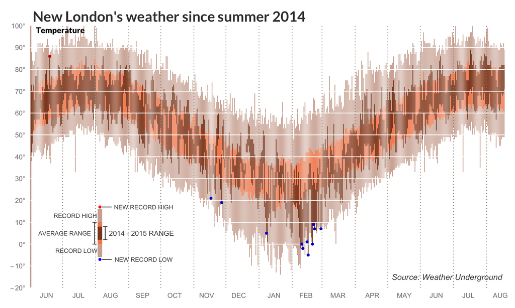